# Lab 3 Hamaniuk-Horetska-Prohorov

Lab assignment 3 Parameter estimation and Unbiasedness of Estimator

Work breakdown:

Roman Prohorov is doing Task1 and his efforts are 33.33 %.  
Mariia Hamaniuk is doing Task2 and her efforts are 33.33 %.  
Daryna Horetska is doing Task3 and summary and her efforts are 33.33 %.

**Task 1** The expected value of the exponential distribution $E(\lambda)$ is $1/\lambda$, so that a good point estimate of the parameter $\theta := 1/\lambda$ is the sample mean $\bar{X}$. Confidence interval for $\theta$ can be formed in several different ways:

1. Using the exact distribution of the statistics $2\lambda n\bar{X}$ (show it is $\chi^2_{2n}$ and then use quantiles of the latter to get the interval endpoints)
2. Using the normal approximation $N(\mu, \sigma^2)$ for $\bar{X}$; the parameters are $\mu = \theta$ and $\sigma^2 = s^2/n$, where $s^2 = \theta^2$ is the population variance (i.e., variance of the original distribution $E(\lambda)$). In other words, we form the Z-statistics
   $$Z := \frac{\sqrt{n}(\bar{X} -
   \theta)}{\theta}$$
   and use the fact that it is approximately standard normal $N(0, 1)$ to find that
   $$P\left(|\theta - \bar{X}| \leq z_\beta
   \frac{\theta}{\sqrt{n}}\right) = P(|Z| \leq z_\beta) = 2\beta -
   1.$$
   In other words, $\theta$ is with probability $2\beta - 1$ within $\bar{X} \pm z_\beta \theta/\sqrt{n}$.
3. The confidence interval constructed above uses the unknown variance $s^2 = \theta^2$ and is of little use in practice. Instead, we can solve the double inequality $|\theta - \bar{X}| \leq z_\beta \theta/\sqrt{n}$ for $\theta$ and get another confidence interval of confidence level $2\beta - 1$ that is independent of the unknown parameter.
4. Another (and a more universal approach) to get rid of the dependence on $\theta$ in (2) is to estimate $s$ via the sample standard error and use approximation of $\bar{X}$ via Student t-distribution

**Task:**

1. Verify that the confidence intervals of level $1 - \alpha$ constructed via methods 1–4 above contain the parameter $\theta = 1/\lambda$ approx. $100(1 - \alpha)\%$ of times
2. Compare their precision (lengths)
3. Give your recommendation as to which of the four methods is the best one and explain your decision

**Problem formulation and discussion:**

1. We need to verify that the interval estimates produced by known rules indeed contain the parameter with probability equal to the confidence level for the exponential distribution E(λ).
2. For exponential distribution E(λ), we have E(X) = 1/λ = θ and Var(X) = 1/λ² = θ². This shows that we can use the sample mean as an estimator for θ.

The reasonable questions to discuss are:

1. How accurate is the coverage - do the confidence intervals really contain the unknown parameter θ with the claimed probability?
2. Which of the four methods will give us the best/most precise/narrowest interval?
3. What happens to intervals when we change n (either make it large or small)?
4. How does the exact chi-squared method compare to approximation methods?

```r
# Initialization of variables
id <- 36
set.seed(id)
theta <- id / 10
alpha_list <- c(0.1, 0.05, 0.01) # levels of alpha
n <- c(30, 50, 100, 200) # sample sizes
M <- 10000 # times to replicate

cat("True parameter theta =", theta, "\n")
```

```
True parameter theta = 3.6
```

```r
cat("This corresponds to lambda =", 1 / theta, "\n\n")
```

```
This corresponds to lambda = 0.2777778
```

**Method 1: Exact chi-squared distribution**

```r
coverage1 <- matrix(0, nrow = length(n), ncol = length(alpha_list))
avgLength1 <- matrix(0, nrow = length(n), ncol = length(alpha_list))
sdLength1 <- matrix(0, nrow = length(n), ncol = length(alpha_list))

for (i in 1:length(n)) {
  ni <- n[i]
  lambda <- 1/theta

  # Generate samples from exponential distribution
  samples <- matrix(rexp(ni * M, rate = lambda), nrow = ni, ncol = M)
  sample_means <- colMeans(samples)

  for (j in 1:length(alpha_list)) {
    alpha <- alpha_list[j]
    confidenceLevel <- 1 - alpha

    # Using the fact that 2*lambda*n*X_bar ~ chi-squared(2n)
    # We need quantiles of chi-squared distribution
    chi_lower <- qchisq(alpha/2, df = 2*ni)
    chi_upper <- qchisq(1 - alpha/2, df = 2*ni)

    # Confidence interval for theta: [2*n*X_bar/chi_upper, 2*n*X_bar/chi_lower]
    lower <- (2 * ni * sample_means) / chi_upper
    upper <- (2 * ni * sample_means) / chi_lower

    coverage <- mean((lower <= theta) & (theta <= upper))
    lengths <- upper - lower
    meanLength <- mean(lengths)
    sdLengths <- sd(lengths)

    coverage1[i, j] <- coverage
    avgLength1[i, j] <- meanLength
    sdLength1[i, j] <- sdLengths
  }
}
```

**Method 2: Normal approximation with known variance**

```r
coverage2 <- matrix(0, nrow = length(n), ncol = length(alpha_list))
avgLength2 <- matrix(0, nrow = length(n), ncol = length(alpha_list))
sdLength2 <- matrix(0, nrow = length(n), ncol = length(alpha_list))

for (i in 1:length(n)) {
  ni <- n[i]
  lambda <- 1/theta

  samples <- matrix(rexp(ni * M, rate = lambda), nrow = ni, ncol = M)
  sample_means <- colMeans(samples)

  for (j in 1:length(alpha_list)) {
    alpha <- alpha_list[j]
    confidenceLevel <- 1 - alpha
    critical <- qnorm(1 - alpha/2)

    # Using known variance sigma^2 = theta^2
    err <- critical * theta / sqrt(ni)
    lower <- sample_means - err
    upper <- sample_means + err

    coverage <- mean((lower <= theta) & (theta <= upper))
    lengths <- upper - lower
    meanLength <- mean(lengths)
    sdLengths <- sd(lengths)

    coverage2[i, j] <- coverage
    avgLength2[i, j] <- meanLength
    sdLength2[i, j] <- sdLengths
  }
}
```

**Method 3: Solving the inequality**

```r
coverage3 <- matrix(0, nrow = length(n), ncol = length(alpha_list))
avgLength3 <- matrix(0, nrow = length(n), ncol = length(alpha_list))
sdLength3 <- matrix(0, nrow = length(n), ncol = length(alpha_list))

for (i in seq_along(n)) {
  ni <- n[i]
  lambda <- 1/theta

  samples <- matrix(rexp(ni * M, rate = lambda), nrow = ni, ncol = M)
  sample_means <- colMeans(samples)

  for (j in seq_along(alpha_list)) {
    alpha <- alpha_list[j]
    z <- qnorm(1 - alpha/2)

    # method 3 interval
    lower <- sample_means / (1 + z / sqrt(ni))
    upper <- sample_means / (1 - z / sqrt(ni))

    coverage3[i,j] <- mean(lower <= theta & theta <= upper)
    lengths <- upper - lower

    avgLength3[i,j] <- mean(lengths)
    sdLength3[i,j] <- sd(lengths)
  }
}
```

**Method 4: Student t-distribution with sample standard error**

```r
coverage4 <- matrix(0, nrow = length(n), ncol = length(alpha_list))
avgLength4 <- matrix(0, nrow = length(n), ncol = length(alpha_list))
sdLength4 <- matrix(0, nrow = length(n), ncol = length(alpha_list))

for (i in 1:length(n)) {
  ni <- n[i]
  lambda <- 1/theta

  samples <- matrix(rexp(ni * M, rate = lambda), nrow = ni, ncol = M)
  sample_means <- colMeans(samples)
  sample_sds <- apply(samples, 2, sd)

  for (j in 1:length(alpha_list)) {
    alpha <- alpha_list[j]
    confidenceLevel <- 1 - alpha
    critical <- qt(1 - alpha/2, df = ni - 1)

    error <- critical * sample_sds / sqrt(ni)
    lower <- sample_means - error
    upper <- sample_means + error

    coverage <- mean((lower <= theta) & (theta <= upper))
    lengths <- upper - lower
    meanLength <- mean(lengths)
    sdLength <- sd(lengths)

    coverage4[i, j] <- coverage
    avgLength4[i, j] <- meanLength
    sdLength4[i, j] <- sdLength
  }
}
```

**Analysis and comparison:**

```r
library(knitr) # for kable()

for (j in 1:length(alpha_list)) {
  alpha <- alpha_list[j]
  confidenceLevel <- 1 - alpha

  cat("Confidence level:", confidenceLevel * 100, "%\n")

  # Coverage Probabilities Table
  cat("Coverage Probabilities and Errors\n")
  comparison_df <- data.frame(
    n = n,
    M1_Coverage = sprintf("%.4f", coverage1[, j]),
    M1_Error = sprintf("%.4f", abs(coverage1[, j] - confidenceLevel)),
    M2_Coverage = sprintf("%.4f", coverage2[, j]),
    M2_Error = sprintf("%.4f", abs(coverage2[, j] - confidenceLevel)),
    M3_Coverage = sprintf("%.4f", coverage3[, j]),
    M3_Error = sprintf("%.4f", abs(coverage3[, j] - confidenceLevel)),
    M4_Coverage = sprintf("%.4f", coverage4[, j]),
    M4_Error = sprintf("%.4f", abs(coverage4[, j] - confidenceLevel))
  )
  colnames(comparison_df) <- c("n", "M1 Cov", "M1 Err", "M2 Cov", "M2 Err",
                                "M3 Cov", "M3 Err", "M4 Cov", "M4 Err")
  print(kable(comparison_df, align = 'c'))

  cat("\n")
  cat(sprintf("Target Coverage: %.4f\n", confidenceLevel))
  cat(sprintf("Best Coverage Accuracy: Method %d (min error = %.4f)\n",
              which.min(c(mean(abs(coverage1[, j] - confidenceLevel)),
                         mean(abs(coverage2[, j] - confidenceLevel)),
                         mean(abs(coverage3[, j] - confidenceLevel)),
                         mean(abs(coverage4[, j] - confidenceLevel)))),
              min(c(mean(abs(coverage1[, j] - confidenceLevel)),
                   mean(abs(coverage2[, j] - confidenceLevel)),
                   mean(abs(coverage3[, j] - confidenceLevel)),
                   mean(abs(coverage4[, j] - confidenceLevel))))))
  cat("------------------------------------------------------------------------")

  # Mean Interval Lengths Table
  cat("\n\nMean Confidence Interval Lengths\n")
  length_df <- data.frame(
    n = n,
    Method1 = sprintf("%.4f", avgLength1[, j]),
    Method2 = sprintf("%.4f", avgLength2[, j]),
    Method3 = sprintf("%.4f", avgLength3[, j]),
    Method4 = sprintf("%.4f", avgLength4[, j])
  )
  colnames(length_df) <- c("n", "M1 (Exact)", "M2 (Normal)", "M3 (Inequality)", "M4 (Student)")
  print(kable(length_df, align = 'c'))

  cat("\n")
  cat(sprintf("Shortest Average Length: Method 1 = %.4f (n=%d)\n",
              min(avgLength1[, j]), n[which.min(avgLength1[, j])]))

  cat("------------------------------------------------------------------------")
  # Relative Efficiency Table
  cat("\n\nRelative Efficiency (Ratio to Method 1)\n")
  efficiency_df <- data.frame(
    n = n,
    Method1 = sprintf("%.4f", rep(1.0, length(n))),
    Method2 = sprintf("%.4f", avgLength2[, j] / avgLength1[, j]),
    Method3 = sprintf("%.4f", avgLength3[, j] / avgLength1[, j]),
    Method4 = sprintf("%.4f", avgLength4[, j] / avgLength1[, j])
  )
  colnames(efficiency_df) <- c("n", "M1 (Exact)", "M2 (Normal)", "M3 (Inequality)", "M4 (Student)")
  print(kable(efficiency_df, align = 'c'))

  cat("========================================================================\n")
  cat("\n")
}
```

```
Confidence level: 90 %
Coverage Probabilities and Errors


|  n  | M1 Cov | M1 Err | M2 Cov | M2 Err | M3 Cov | M3 Err | M4 Cov | M4 Err |
|:---:|:------:|:------:|:------:|:------:|:------:|:------:|:------:|:------:|
| 30  | 0.9050 | 0.0050 | 0.9048 | 0.0048 | 0.9023 | 0.0023 | 0.8780 | 0.0220 |
| 50  | 0.8983 | 0.0017 | 0.9013 | 0.0013 | 0.8990 | 0.0010 | 0.8846 | 0.0154 |
| 100 | 0.8961 | 0.0039 | 0.8980 | 0.0020 | 0.9012 | 0.0012 | 0.8931 | 0.0069 |
| 200 | 0.8992 | 0.0008 | 0.9017 | 0.0017 | 0.9053 | 0.0053 | 0.8983 | 0.0017 |

Target Coverage: 0.9000
Best Coverage Accuracy: Method 2 (min error = 0.0024)
------------------------------------------------------------------------

Mean Confidence Interval Lengths


|  n  | M1 (Exact) | M2 (Normal) | M3 (Inequality) | M4 (Student) |
|:---:|:----------:|:-----------:|:---------------:|:------------:|
| 30  |   2.2717   |   2.1622    |     2.3798      |    2.1593    |
| 50  |   1.7241   |   1.6748    |     1.7703      |    1.6770    |
| 100 |   1.2017   |   1.1843    |     1.2166      |    1.1803    |
| 200 |   0.8436   |   0.8374    |     0.8486      |    0.8363    |

Shortest Average Length: Method 1 = 0.8436 (n=200)
------------------------------------------------------------------------

Relative Efficiency (Ratio to Method 1)


|  n  | M1 (Exact) | M2 (Normal) | M3 (Inequality) | M4 (Student) |
|:---:|:----------:|:-----------:|:---------------:|:------------:|
| 30  |   1.0000   |   0.9518    |     1.0476      |    0.9505    |
| 50  |   1.0000   |   0.9715    |     1.0268      |    0.9727    |
| 100 |   1.0000   |   0.9855    |     1.0125      |    0.9822    |
| 200 |   1.0000   |   0.9927    |     1.0059      |    0.9913    |
========================================================================

Confidence level: 95 %
```

[output cut: 61 more lines]

```
| 200 |   1.3305   |   1.3114    |     1.3559      |    1.3162    |

Shortest Average Length: Method 1 = 1.3305 (n=200)
------------------------------------------------------------------------

Relative Efficiency (Ratio to Method 1)


|  n  | M1 (Exact) | M2 (Normal) | M3 (Inequality) | M4 (Student) |
|:---:|:----------:|:-----------:|:---------------:|:------------:|
| 30  |   1.0000   |   0.9072    |     1.1665      |    0.9385    |
| 50  |   1.0000   |   0.9440    |     1.0883      |    0.9649    |
| 100 |   1.0000   |   0.9716    |     1.0401      |    0.9781    |
| 200 |   1.0000   |   0.9856    |     1.0191      |    0.9892    |
========================================================================
```

**Visualization: Coverage Probabilities**

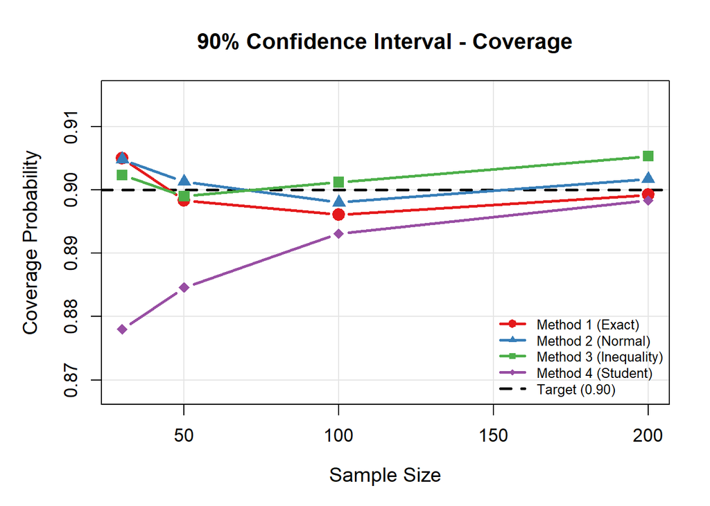

```r
colors <- c("#E41A1C", "#377EB8", "#4DAF4A", "#984EA3")
method_names <- c("Method 1 (Exact)", "Method 2 (Normal)",
                  "Method 3 (Inequality)", "Method 4 (Student)")

par(mfrow = c(1, 1), mar = c(5, 5, 4, 2))
j <- 1
alpha <- alpha_list[j]
conf_level <- 1 - alpha

all_coverage <- c(coverage1[, j], coverage2[, j], coverage3[, j], coverage4[, j])
y_min <- max(0.80, min(all_coverage) - 0.01)
y_max <- min(1.00, max(all_coverage) + 0.01)

plot(n, coverage1[, j], type = "n",
     ylim = c(y_min, y_max),
     xlab = "Sample Size",
     ylab = "Coverage Probability",
     main = sprintf("%.0f%% Confidence Interval - Coverage",
                    conf_level * 100),
     panel.first = grid(col = "gray90", lty = 1),
     cex.lab = 1.2, cex.main = 1.3, cex.axis = 1.1)

abline(h = conf_level, lty = 2, col = "black", lwd = 2.5)

lines(n, coverage1[, j], type = "b", pch = 19, col = colors[1], lwd = 2.5, cex = 1.4)
lines(n, coverage2[, j], type = "b", pch = 17, col = colors[2], lwd = 2.5, cex = 1.4)
lines(n, coverage3[, j], type = "b", pch = 15, col = colors[3], lwd = 2.5, cex = 1.4)
lines(n, coverage4[, j], type = "b", pch = 18, col = colors[4], lwd = 2.5, cex = 1.4)

legend("bottomright",
       legend = c(method_names, sprintf("Target (%.2f)", conf_level)),
       col = c(colors, "black"),
       pch = c(19, 17, 15, 18, NA),
       lty = c(1, 1, 1, 1, 2),
       lwd = 2.5,
       bty = "n",
       cex = 0.8)
```

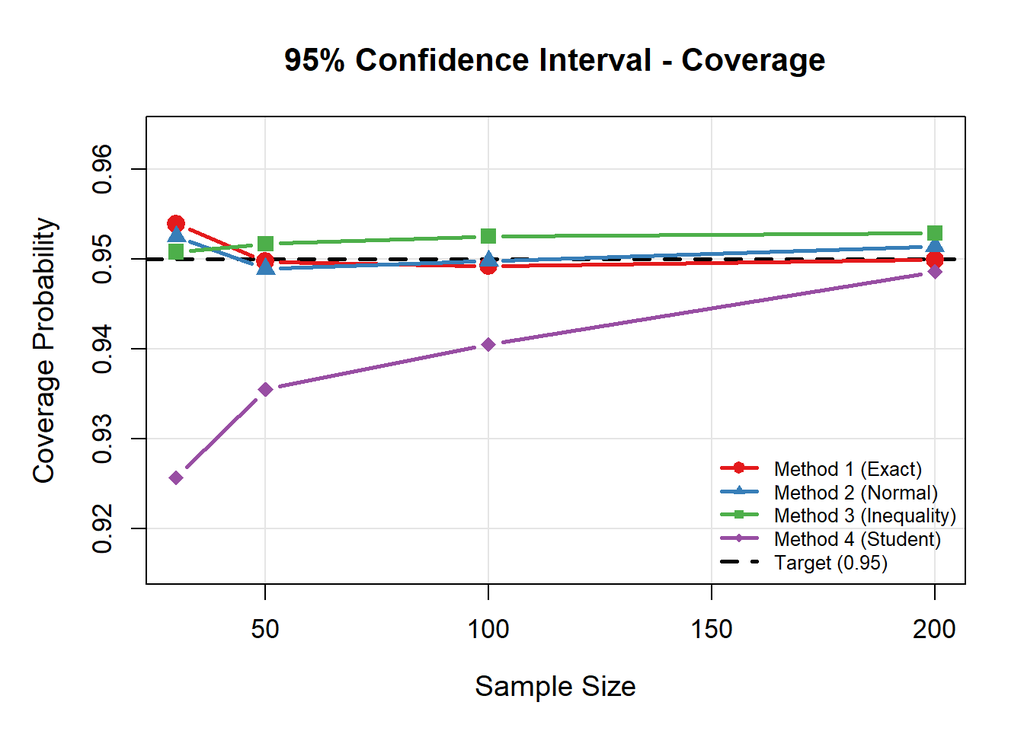

```r
par(mfrow = c(1, 1), mar = c(5, 5, 4, 2))
j <- 2
alpha <- alpha_list[j]
conf_level <- 1 - alpha

all_coverage <- c(coverage1[, j], coverage2[, j], coverage3[, j], coverage4[, j])
y_min <- max(0.80, min(all_coverage) - 0.01)
y_max <- min(1.00, max(all_coverage) + 0.01)

plot(n, coverage1[, j], type = "n",
     ylim = c(y_min, y_max),
     xlab = "Sample Size",
     ylab = "Coverage Probability",
     main = sprintf("%.0f%% Confidence Interval - Coverage",
                    conf_level * 100),
     panel.first = grid(col = "gray90", lty = 1),
     cex.lab = 1.2, cex.main = 1.3, cex.axis = 1.1)

abline(h = conf_level, lty = 2, col = "black", lwd = 2.5)

lines(n, coverage1[, j], type = "b", pch = 19, col = colors[1], lwd = 2.5, cex = 1.4)
lines(n, coverage2[, j], type = "b", pch = 17, col = colors[2], lwd = 2.5, cex = 1.4)
lines(n, coverage3[, j], type = "b", pch = 15, col = colors[3], lwd = 2.5, cex = 1.4)
lines(n, coverage4[, j], type = "b", pch = 18, col = colors[4], lwd = 2.5, cex = 1.4)

legend("bottomright",
       legend = c(method_names, sprintf("Target (%.2f)", conf_level)),
       col = c(colors, "black"),
       pch = c(19, 17, 15, 18, NA),
       lty = c(1, 1, 1, 1, 2),
       lwd = 2.5,
       bty = "n",
       cex = 0.8)
```

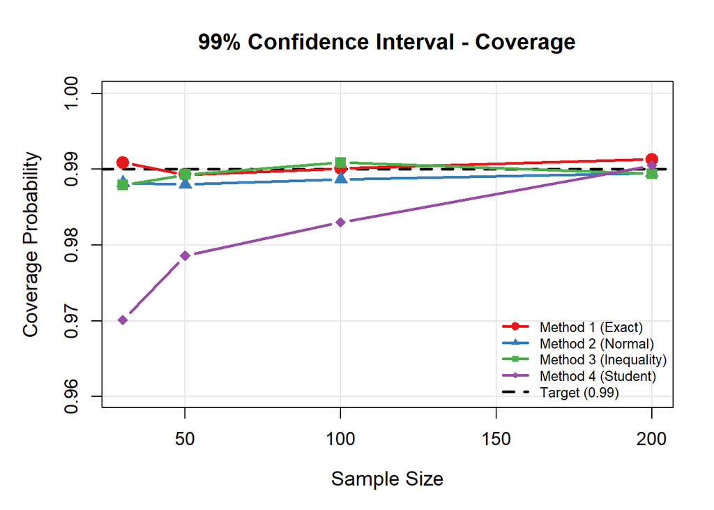

```r
par(mfrow = c(1, 1), mar = c(5, 5, 4, 2))
j <- 3
alpha <- alpha_list[j]
conf_level <- 1 - alpha

all_coverage <- c(coverage1[, j], coverage2[, j], coverage3[, j], coverage4[, j])
y_min <- max(0.80, min(all_coverage) - 0.01)
y_max <- min(1.00, max(all_coverage) + 0.01)

plot(n, coverage1[, j], type = "n",
     ylim = c(y_min, y_max),
     xlab = "Sample Size",
     ylab = "Coverage Probability",
     main = sprintf("%.0f%% Confidence Interval - Coverage",
                    conf_level * 100),
     panel.first = grid(col = "gray90", lty = 1),
     cex.lab = 1.2, cex.main = 1.3, cex.axis = 1.1)

abline(h = conf_level, lty = 2, col = "black", lwd = 2.5)

lines(n, coverage1[, j], type = "b", pch = 19, col = colors[1], lwd = 2.5, cex = 1.4)
lines(n, coverage2[, j], type = "b", pch = 17, col = colors[2], lwd = 2.5, cex = 1.4)
lines(n, coverage3[, j], type = "b", pch = 15, col = colors[3], lwd = 2.5, cex = 1.4)
lines(n, coverage4[, j], type = "b", pch = 18, col = colors[4], lwd = 2.5, cex = 1.4)

legend("bottomright",
       legend = c(method_names, sprintf("Target (%.2f)", conf_level)),
       col = c(colors, "black"),
       pch = c(19, 17, 15, 18, NA),
       lty = c(1, 1, 1, 1, 2),
       lwd = 2.5,
       bty = "n",
       cex = 0.8)
```

**Visualization: Mean Confidence Interval Lengths**

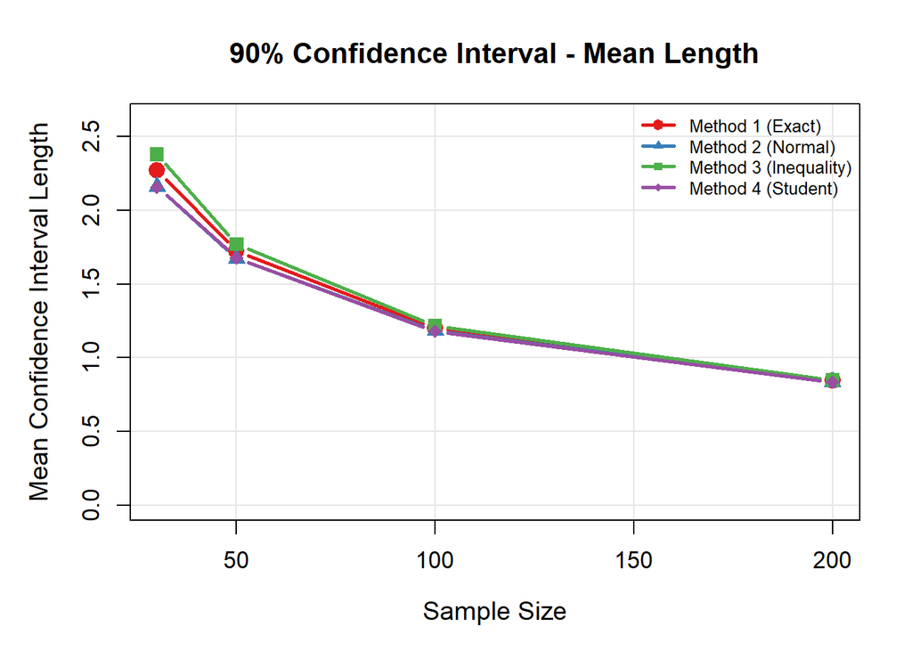

```r
par(mfrow = c(1, 1), mar = c(5, 5, 4, 2))
j <- 1
alpha <- alpha_list[j]
conf_level <- 1 - alpha

all_lengths <- c(avgLength1[, j], avgLength2[, j], avgLength3[, j], avgLength4[, j])
y_max <- max(all_lengths) * 1.1

plot(n, avgLength1[, j], type = "n",
     ylim = c(0, y_max),
     xlab = "Sample Size",
     ylab = "Mean Confidence Interval Length",
     main = sprintf("%.0f%% Confidence Interval - Mean Length",
                    conf_level * 100),
     panel.first = grid(col = "gray90", lty = 1),
     cex.lab = 1.2, cex.main = 1.3, cex.axis = 1.1)

lines(n, avgLength1[, j], type = "b", pch = 19, col = colors[1], lwd = 2.5, cex = 1.4)
lines(n, avgLength2[, j], type = "b", pch = 17, col = colors[2], lwd = 2.5, cex = 1.4)
lines(n, avgLength3[, j], type = "b", pch = 15, col = colors[3], lwd = 2.5, cex = 1.4)
lines(n, avgLength4[, j], type = "b", pch = 18, col = colors[4], lwd = 2.5, cex = 1.4)

legend("topright",
       legend = method_names,
       col = colors,
       pch = c(19, 17, 15, 18),
       lty = 1,
       lwd = 2.5,
       bty = "n",
       cex = 0.8)
```

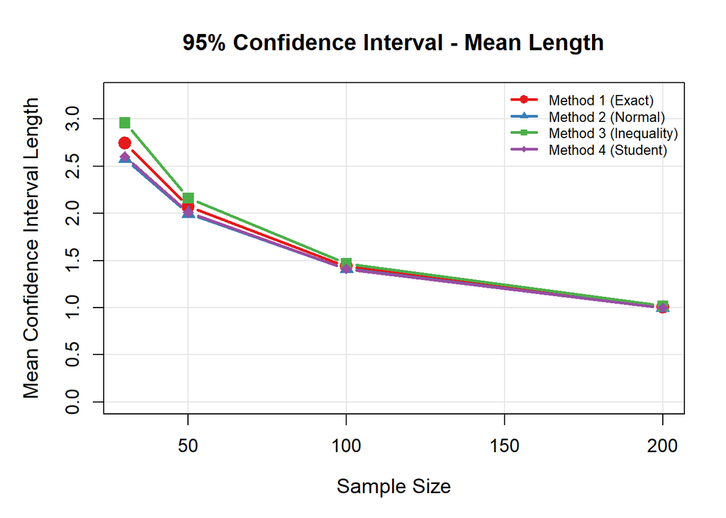

```r
par(mfrow = c(1, 1), mar = c(5, 5, 4, 2))
j <- 2
alpha <- alpha_list[j]
conf_level <- 1 - alpha

all_lengths <- c(avgLength1[, j], avgLength2[, j], avgLength3[, j], avgLength4[, j])
y_max <- max(all_lengths) * 1.1

plot(n, avgLength1[, j], type = "n",
     ylim = c(0, y_max),
     xlab = "Sample Size",
     ylab = "Mean Confidence Interval Length",
     main = sprintf("%.0f%% Confidence Interval - Mean Length",
                    conf_level * 100),
     panel.first = grid(col = "gray90", lty = 1),
     cex.lab = 1.2, cex.main = 1.3, cex.axis = 1.1)

lines(n, avgLength1[, j], type = "b", pch = 19, col = colors[1], lwd = 2.5, cex = 1.4)
lines(n, avgLength2[, j], type = "b", pch = 17, col = colors[2], lwd = 2.5, cex = 1.4)
lines(n, avgLength3[, j], type = "b", pch = 15, col = colors[3], lwd = 2.5, cex = 1.4)
lines(n, avgLength4[, j], type = "b", pch = 18, col = colors[4], lwd = 2.5, cex = 1.4)

legend("topright",
       legend = method_names,
       col = colors,
       pch = c(19, 17, 15, 18),
       lty = 1,
       lwd = 2.5,
       bty = "n",
       cex = 0.8)
```

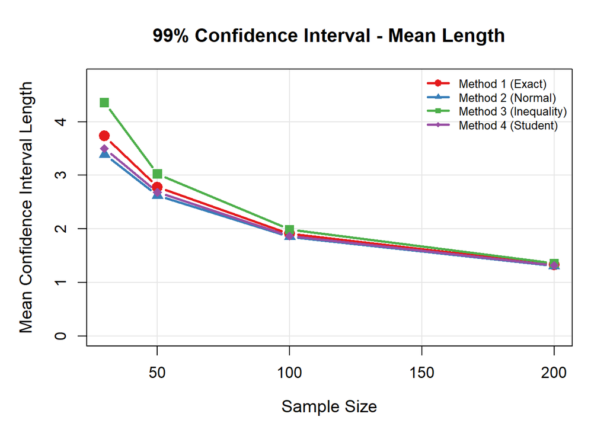

```r
par(mfrow = c(1, 1), mar = c(5, 5, 4, 2))
j <- 3
alpha <- alpha_list[j]
conf_level <- 1 - alpha

all_lengths <- c(avgLength1[, j], avgLength2[, j], avgLength3[, j], avgLength4[, j])
y_max <- max(all_lengths) * 1.1

plot(n, avgLength1[, j], type = "n",
     ylim = c(0, y_max),
     xlab = "Sample Size",
     ylab = "Mean Confidence Interval Length",
     main = sprintf("%.0f%% Confidence Interval - Mean Length",
                    conf_level * 100),
     panel.first = grid(col = "gray90", lty = 1),
     cex.lab = 1.2, cex.main = 1.3, cex.axis = 1.1)

lines(n, avgLength1[, j], type = "b", pch = 19, col = colors[1], lwd = 2.5, cex = 1.4)
lines(n, avgLength2[, j], type = "b", pch = 17, col = colors[2], lwd = 2.5, cex = 1.4)
lines(n, avgLength3[, j], type = "b", pch = 15, col = colors[3], lwd = 2.5, cex = 1.4)
lines(n, avgLength4[, j], type = "b", pch = 18, col = colors[4], lwd = 2.5, cex = 1.4)

legend("topright",
       legend = method_names,
       col = colors,
       pch = c(19, 17, 15, 18),
       lty = 1,
       lwd = 2.5,
       bty = "n",
       cex = 0.8)
```

**Justification:**

**Method 1 (Exact Chi-Squared):** For X₁, …, Xₙ ~ Exp(λ), the sum ∑Xᵢ ~ Gamma(n, λ). Using the relationship between Gamma and chi-squared distributions, we have:
$$2\lambda n\bar{X} \sim \chi^2_{2n}$$

This gives us the exact confidence interval:
$$P\left(\frac{2n\bar{X}}{\chi^2_{1-\alpha/2, 2n}}
\leq \theta \leq \frac{2n\bar{X}}{\chi^2_{\alpha/2, 2n}}\right) =
1-\alpha$$

**Method 2 (Normal Approximation):** By the Central Limit Theorem, for large n:
$$\bar{X}
\xrightarrow{d} N(\theta, \theta^2/n)$$

Standardizing:
$$Z =
\frac{\sqrt{n}(\bar{X} - \theta)}{\theta} \approx N(0, 1)$$

This gives:
$$P\left(\bar{X} -
z_{\alpha/2}\frac{\theta}{\sqrt{n}} \leq \theta \leq \bar{X} +
z_{\alpha/2}\frac{\theta}{\sqrt{n}}\right) = 1-\alpha$$

**Method 3 (Solving the Inequality):**

From Method 2 we have the approximate confidence statement
$$P\left(|\bar{X} - \theta| \le z_{\alpha/2}\frac{\theta}{\sqrt{n}}\right)
\approx 1 - \alpha.$$

This inequality contains the unknown parameter $\theta$ on both sides, so we solve it explicitly for $\theta$. The condition
$$|\bar{X} - \theta| \le z_{\alpha/2}\frac{\theta}{\sqrt{n}}$$
is equivalent to
$$\bar{X} - z_{\alpha/2}\frac{\theta}{\sqrt{n}} \le \theta \le \bar{X} +
z_{\alpha/2}\frac{\theta}{\sqrt{n}}.$$

Rearranging the left inequality gives
$$\theta \ge \frac{\bar{X}}{1 + \frac{z_{\alpha/2}}{\sqrt{n}}},$$
and rearranging the right inequality gives
$$\theta \le \frac{\bar{X}}{1 - \frac{z_{\alpha/2}}{\sqrt{n}}}.$$

Thus we obtain the parameter-free confidence interval
$$P\left(
\frac{\bar{X}}{1 + \frac{z_{\alpha/2}}{\sqrt{n}}}
\;\le\;
\theta
\;\le\;
\frac{\bar{X}}{1 - \frac{z_{\alpha/2}}{\sqrt{n}}}
\right)
\approx 1 - \alpha.$$

**Method 4 (Student t-distribution):** Using the sample standard error S instead of the population variance, and approximating the distribution with Student’s t:
$$\frac{\sqrt{n}(\bar{X} - \theta)}{S} \approx
t_{n-1}$$

This gives:
$$P\left(\bar{X} -
t_{n-1,\alpha/2}\frac{S}{\sqrt{n}} \leq \theta \leq \bar{X} +
t_{n-1,\alpha/2}\frac{S}{\sqrt{n}}\right) = 1-\alpha$$

**Conclusion:**

The simulation results confirm the theoretical properties of confidence intervals for the exponential distribution with parameter $\theta = 3.6$:

**For practical applications where you want a parameter-free method:**

**Methods with limitations:**

- **Method 2**: Cannot be used in practice because it requires knowing the true parameter $\theta$ to calculate the margin of error $(z_{\alpha/2} \cdot \theta/\sqrt{n})$. Since $\theta$ is unknown (it’s what we’re trying to estimate), this method is theoretically sound but practically impossible to implement. It serves as a benchmark in simulations where we know the true parameter, demonstrating that the normal approximation is valid for the exponential distribution.

**Task 2**

**Problem formulation and discussion (what is a reasonable question to discuss):** 1. We have to verify that the interval estimates produced by known rules indeed contain the parameter with probability equal to the confidence level. 2. We are given the Poisson distribution so E(X) = theta and Var(X) = theta, where theta > 0; That’s shows us that we can use MME (MOM) to estimate unknown parameter theta (the estimator for theta = sample mean). Also later on we will see that we can apply CLT here which is useful.

So the reasonable questions to discuss are: 1. How good or how accurate the coverage is, do the confidence intervals really contains unknown parameter theta with claimed probability? 2. Which of methods (2/3/4) that we are going to use will give us the best/ the most precise/the narrowest interval? 3. What will happen to intervals if we change n (either make it large or small)? **R code** with comments:

```r
#initialization of our variables
id <- 36
set.seed(id)
theta <- id/10
alpha_list <- c(0.1, 0.05, 0.01) # levels of alpha
n <- c(30, 50, 100, 200) # sample sizes
M <- 10000 #times to replicate
```

Part 2 from task 1:

```r
coverage2 <- matrix(0, nrow = length(n), ncol = length(alpha_list))
avgLength2 <- matrix(0, nrow = length(n), ncol = length(alpha_list)) #avarage length of confidence intervals we just add them and devide on number of them
sdLength2 <- matrix(0, nrow = length(n), ncol = length(alpha_list))

for (i in 1:length(n)){
  ni <- n[i]
  #cat("sample size = ", ni, "\n")
  samples <- matrix (rpois(ni * M, lambda = theta), nrow = ni, ncol = M) #just generatind n samples using rpois
  sample_means <- colMeans(samples)
  for (j in 1:length(alpha_list)){
    alpha <- alpha_list[j]
    confidenceLevel <- 1 - alpha
    critical <- qnorm(1-alpha/2)

    err <- critical * sqrt(theta / ni)
    lower <- sample_means - err
    upper <- sample_means +err

    coverage <- mean((lower <= theta) & (theta <= upper))
    lengths <- upper - lower
    meanLength <- mean(lengths)
    sdLengths <- sd(lengths)

    coverage2[i, j] <- coverage
    avgLength2[i, j] <- meanLength
    sdLength2[i, j] <- sdLengths

#cat("confidence level = ", confidenceLevel * 100, "%\n")
    #cat(sprintf("coverage probability: %.4f and expected: %.4f", coverage, confidenceLevel), "\n")
    #cat("coverage error: ",abs(coverage - confidenceLevel) * 100, "\n")
    #cat("mean critical interval length: ", meanLength, "\n")
    #cat("SD of critical length  ", sdLengths, "\n")
    #cat("сritical value ", critical, "\n\n")
  }
}
```

part 3 from task 1

```r
coverage3 <- matrix(0, nrow = length(n), ncol = length(alpha_list))
avgLength3 <- matrix(0, nrow = length(n), ncol = length(alpha_list)) #avarage length of confidence intervals we just add them and devide on number of them
sdLength3 <- matrix(0, nrow = length(n), ncol = length(alpha_list))

for (i in 1:length(n)) {
  ni <- n[i]
  #cat("sample size =", ni, "\n")

  samples <- matrix(rpois(ni * M, lambda = theta), nrow = ni, ncol = M)
  sample_means <- colMeans(samples)

  for (j in 1:length(alpha_list)) {
    alpha <- alpha_list[j]
    confidenceLevel <- 1 - alpha
    critical <- qnorm(1 - alpha/2)

    a <- 1
    b <- -(2 * sample_means + critical^2 /ni)
    c <- sample_means^2

    discriminant <- b^2 - 4 * a * c

    lower <- (-b - sqrt(discriminant)) / (2 * a)
    upper <- (-b + sqrt(discriminant)) / (2 * a)

    coverage <- mean((lower <= theta) & (theta <= upper))
    lengths <- upper - lower
    meanLength <- mean(lengths)
    sdLength <- sd(lengths)

    coverage3[i, j] <- coverage
    avgLength3[i, j] <- meanLength
    sdLength3[i, j] <- sdLength

    #cat("confidence level = ", confidenceLevel * 100, "%\n")
    #cat(sprintf("coverage probability: %.4f and expected: %.4f", coverage, confidenceLevel), "\n")
    #cat("coverage error: ", abs(coverage - confidenceLevel) * 100, "\n")
    #cat("mean critical interval length: ", meanLength, "\n")
    #cat("SD of critical length  ", sdLength, "\n")
    #cat("сritical value ", critical, "\n\n")
  }
}
```

part 4 from task 1

```r
coverage4 <- matrix(0, nrow = length(n), ncol = length(alpha_list))
avgLength4 <- matrix(0, nrow = length(n), ncol = length(alpha_list)) #avarage length of confidence intervals we just add them and devide on number of them
sdLength4 <- matrix(0, nrow = length(n), ncol = length(alpha_list))
for (i in 1:length(n)) {
  ni <- n[i]
  #cat("sample size =", ni, "\n")

  samples <- matrix(rpois(ni * M, lambda = theta), nrow = ni, ncol = M)
  sample_means <- colMeans(samples)
  sample_sds <- apply(samples, 2, sd)

  for (j in 1:length(alpha_list)) {
    alpha <- alpha_list[j]
    confidenceLevel <- 1 - alpha
    critical <- qt(1 - alpha/2, df = ni - 1)

    error <- critical * sample_sds / sqrt(ni)
    lower <- sample_means - error
    upper <- sample_means + error

    coverage <- mean((lower <= theta) & (theta <= upper))
    lengths <- upper - lower
    meanLength <- mean(lengths)
    sdLength <- sd(lengths)

    coverage4[i, j] <- coverage
    avgLength4[i, j] <- meanLength
    sdLength4[i, j] <- sdLength
    #cat("confidence level = ", confidenceLevel * 100, "%\n")
    #cat(sprintf("coverage probability: %.4f and expected: %.4f", coverage, confidenceLevel), "\n")
    #cat("coverage error: ",abs(coverage - confidenceLevel) * 100, "\n")
    #cat("mean critical interval length: ", meanLength, "\n")
    #cat("SD of critical length  ", sdLength, "\n")
    #cat("сritical value ", critical, "\n\n")
  }
}
```

Analysis and comperasion:

```r
for (j in 1:length(alpha_list)) {
  alpha <- alpha_list[j]
  confidenceLevel <- 1 - alpha
  comparison_df <- data.frame(
    n = n,
    Method2 = coverage2[, j],
    Method3 = coverage3[, j],
    Method4 = coverage4[, j],
    M2_Error = abs(coverage2[, j] - confidenceLevel),
    M3_Error = abs(coverage3[, j] - confidenceLevel),
    M4_Error = abs(coverage4[, j] - confidenceLevel)
  )
  print(comparison_df, digits = 4)

  length_df <- data.frame(
    n = n,
    Method2 = avgLength2[, j],
    Method3 = avgLength3[, j],
    Method4 = avgLength4[, j]
  )
  print(length_df, digits = 4)

  efficiency_df <- data.frame(
    n = n,
    Method2 = rep(1.0, length(n)),
    Method3 = avgLength3[, j] / avgLength2[, j],
    Method4 = avgLength4[, j] / avgLength2[, j]
  )
  print(efficiency_df, digits = 4)
}
```

```
    n Method2 Method3 Method4 M2_Error M3_Error M4_Error
1  30  0.9103  0.9086  0.9024   0.0103   0.0086   0.0024
2  50  0.9031  0.9069  0.8998   0.0031   0.0069   0.0002
3 100  0.8962  0.9019  0.9026   0.0038   0.0019   0.0026
4 200  0.9063  0.9017  0.8963   0.0063   0.0017   0.0037
    n Method2 Method3 Method4
1  30  1.1396  1.1422  1.1643
2  50  0.8827  0.8831  0.8948
3 100  0.6242  0.6247  0.6286
4 200  0.4414  0.4415  0.4428
    n Method2 Method3 Method4
1  30       1   1.002   1.022
2  50       1   1.000   1.014
3 100       1   1.001   1.007
4 200       1   1.000   1.003
```

[output cut: 30 more lines]

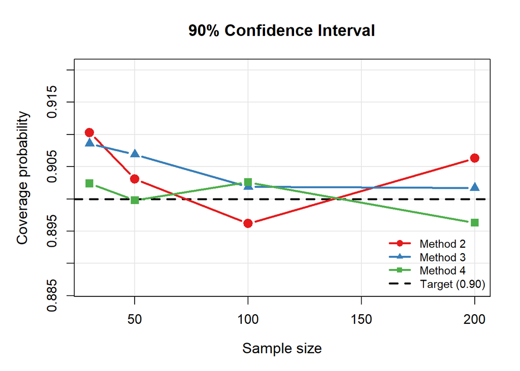

```r
colors <- c("#E41A1C", "#377EB8", "#4DAF4A")
method_names <- c("Method 2", "Method 3", "Method 4")

par(mfrow = c(1, 1), mar = c(5, 5, 4, 2))
j <- 1
alpha <- alpha_list[j]
conf_level <- 1 - alpha

all_coverage <- c(coverage2[, j], coverage3[, j], coverage4[, j])
y_min <- max(0.80, min(all_coverage) - 0.01)
y_max <- min(1.00, max(all_coverage) + 0.01)

plot(n, coverage2[, j], type = "n",
     ylim = c(y_min, y_max),
     xlab = "Sample size",
     ylab = "Coverage probability",
     main = sprintf("%.0f%% Confidence Interval",
                    conf_level * 100),
     panel.first = grid(col = "gray90", lty = 1),
     cex.lab = 1.2, cex.main = 1.3, cex.axis = 1.1)

abline(h = conf_level, lty = 2, col = "black", lwd = 2.5)

lines(n, coverage2[, j], type = "b", pch = 19, col = colors[1], lwd = 2.5, cex = 1.4)
lines(n, coverage3[, j], type = "b", pch = 17, col = colors[2], lwd = 2.5, cex = 1.4)
lines(n, coverage4[, j], type = "b", pch = 15, col = colors[3], lwd = 2.5, cex = 1.4)

legend("bottomright",
       legend = c(method_names, sprintf("Target (%.2f)", conf_level)),
       col = c(colors, "black"),
       pch = c(19, 17, 15, NA),
       lty = c(1, 1, 1, 2),
       lwd = 2.5,
       bty = "n",
       cex = 0.9)
```

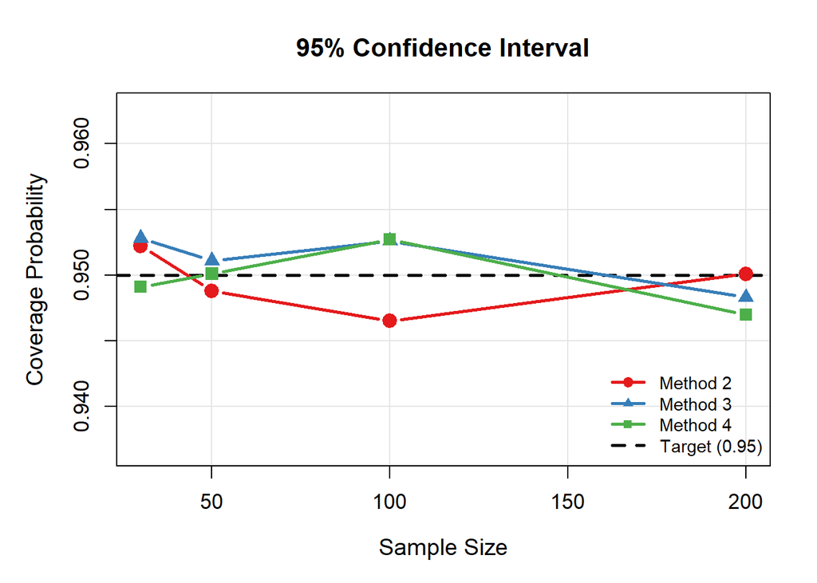

```r
par(mfrow = c(1, 1), mar = c(5, 5, 4, 2))
j <- 2
alpha <- alpha_list[j]
conf_level <- 1 - alpha

all_coverage <- c(coverage2[, j], coverage3[, j], coverage4[, j])
y_min <- max(0.80, min(all_coverage) - 0.01)
y_max <- min(1.00, max(all_coverage) + 0.01)

plot(n, coverage2[, j], type = "n",
     ylim = c(y_min, y_max),
     xlab = "Sample Size",
     ylab = "Coverage Probability",
     main = sprintf("%.0f%% Confidence Interval",
                    conf_level * 100),
     panel.first = grid(col = "gray90", lty = 1),
     cex.lab = 1.2, cex.main = 1.3, cex.axis = 1.1)

abline(h = conf_level, lty = 2, col = "black", lwd = 2.5)

lines(n, coverage2[, j], type = "b", pch = 19, col = colors[1], lwd = 2.5, cex = 1.4)
lines(n, coverage3[, j], type = "b", pch = 17, col = colors[2], lwd = 2.5, cex = 1.4)
lines(n, coverage4[, j], type = "b", pch = 15, col = colors[3], lwd = 2.5, cex = 1.4)

legend("bottomright",
       legend = c(method_names, sprintf("Target (%.2f)", conf_level)),
       col = c(colors, "black"),
       pch = c(19, 17, 15, NA),
       lty = c(1, 1, 1, 2),
       lwd = 2.5,
       bty = "n",
       cex = 0.9)
```

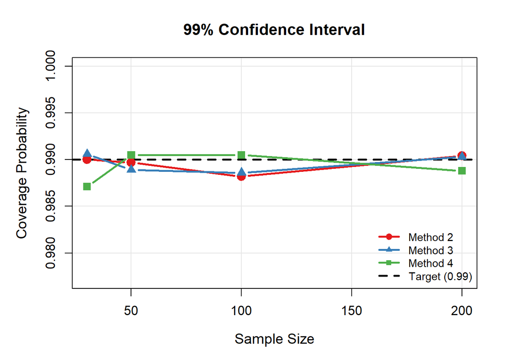

```r
par(mfrow = c(1, 1), mar = c(5, 5, 4, 2))
j <- 3
alpha <- alpha_list[j]
conf_level <- 1 - alpha

all_coverage <- c(coverage2[, j], coverage3[, j], coverage4[, j])
y_min <- max(0.80, min(all_coverage) - 0.01)
y_max <- min(1.00, max(all_coverage) + 0.01)

plot(n, coverage2[, j], type = "n",
     ylim = c(y_min, y_max),
     xlab = "Sample Size",
     ylab = "Coverage Probability",
     main = sprintf("%.0f%% Confidence Interval", conf_level * 100),
     panel.first = grid(col = "gray90", lty = 1),
     cex.lab = 1.2, cex.main = 1.3, cex.axis = 1.1)

abline(h = conf_level, lty = 2, col = "black", lwd = 2.5)

lines(n, coverage2[, j], type = "b", pch = 19, col = colors[1], lwd = 2.5, cex = 1.4)
lines(n, coverage3[, j], type = "b", pch = 17, col = colors[2], lwd = 2.5, cex = 1.4)
lines(n, coverage4[, j], type = "b", pch = 15, col = colors[3], lwd = 2.5, cex = 1.4)

legend("bottomright",
       legend = c(method_names, sprintf("Target (%.2f)", conf_level)),
       col = c(colors, "black"),
       pch = c(19, 17, 15, NA),
       lty = c(1, 1, 1, 2),
       lwd = 2.5,
       bty = "n",
       cex = 0.9)
```

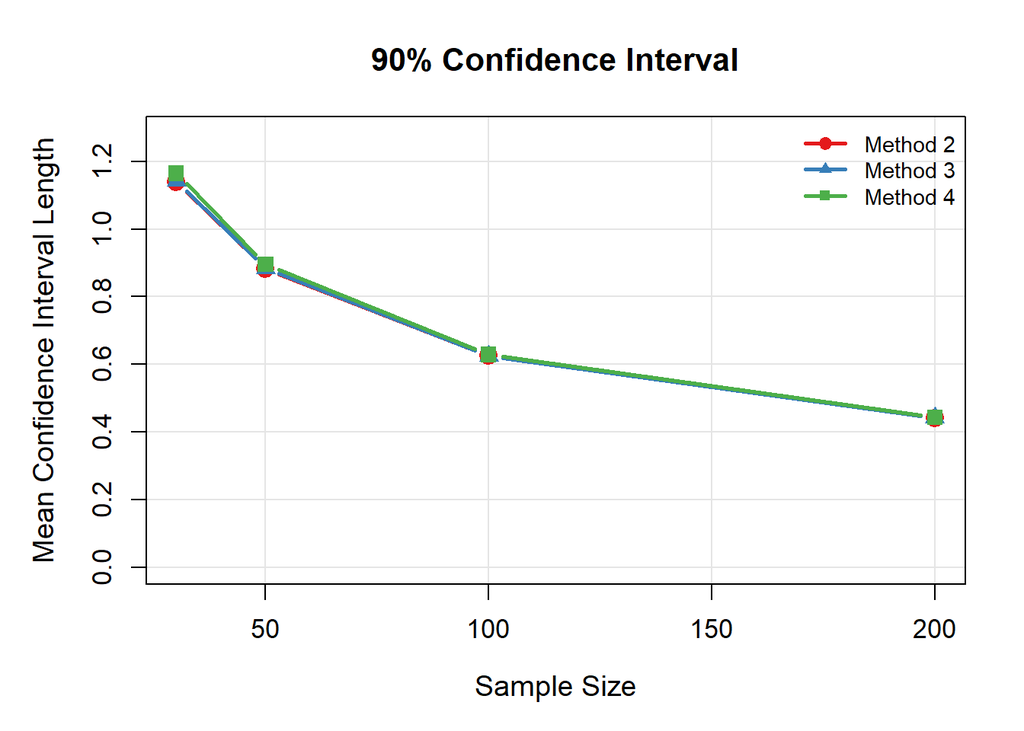

```r
par(mfrow = c(1, 1), mar = c(5, 5, 4, 2))
j <- 1
alpha <- alpha_list[j]
conf_level <- 1 - alpha

all_lengths <- c(avgLength2[, j], avgLength3[, j], avgLength4[, j])
y_max <- max(all_lengths) * 1.1

plot(n, avgLength2[, j], type = "n",
     ylim = c(0, y_max),
     xlab = "Sample Size",
     ylab = "Mean Confidence Interval Length",
     main = sprintf("%.0f%% Confidence Interval",conf_level * 100),
     panel.first = grid(col = "gray90", lty = 1),
     cex.lab = 1.2, cex.main = 1.3, cex.axis = 1.1)

lines(n, avgLength2[, j], type = "b", pch = 19, col = colors[1], lwd = 2.5, cex = 1.4)
lines(n, avgLength3[, j], type = "b", pch = 17, col = colors[2], lwd = 2.5, cex = 1.4)
lines(n, avgLength4[, j], type = "b", pch = 15, col = colors[3], lwd = 2.5, cex = 1.4)

legend("topright",
       legend = method_names,
       col = colors,
       pch = c(19, 17, 15),
       lty = 1,
       lwd = 2.5,
       bty = "n",
       cex = 0.9)
```

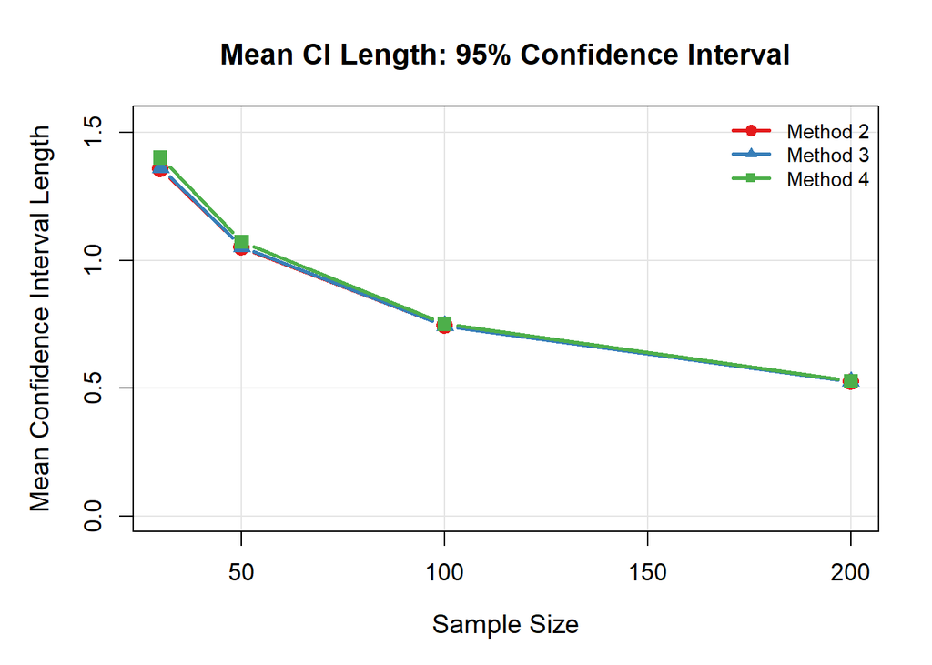

```r
par(mfrow = c(1, 1), mar = c(5, 5, 4, 2))
j <- 2
alpha <- alpha_list[j]
conf_level <- 1 - alpha

all_lengths <- c(avgLength2[, j], avgLength3[, j], avgLength4[, j])
y_max <- max(all_lengths) * 1.1

plot(n, avgLength2[, j], type = "n",
     ylim = c(0, y_max),
     xlab = "Sample Size",
     ylab = "Mean Confidence Interval Length",
     main = sprintf("Mean CI Length: %.0f%% Confidence Interval",
                    conf_level * 100, alpha),
     panel.first = grid(col = "gray90", lty = 1),
     cex.lab = 1.2, cex.main = 1.3, cex.axis = 1.1)
lines(n, avgLength2[, j], type = "b", pch = 19, col = colors[1], lwd = 2.5, cex = 1.4)
lines(n, avgLength3[, j], type = "b", pch = 17, col = colors[2], lwd = 2.5, cex = 1.4)
lines(n, avgLength4[, j], type = "b", pch = 15, col = colors[3], lwd = 2.5, cex = 1.4)

legend("topright",
       legend = method_names,
       col = colors,
       pch = c(19, 17, 15),
       lty = 1,
       lwd = 2.5,
       bty = "n",
       cex = 0.9)
```

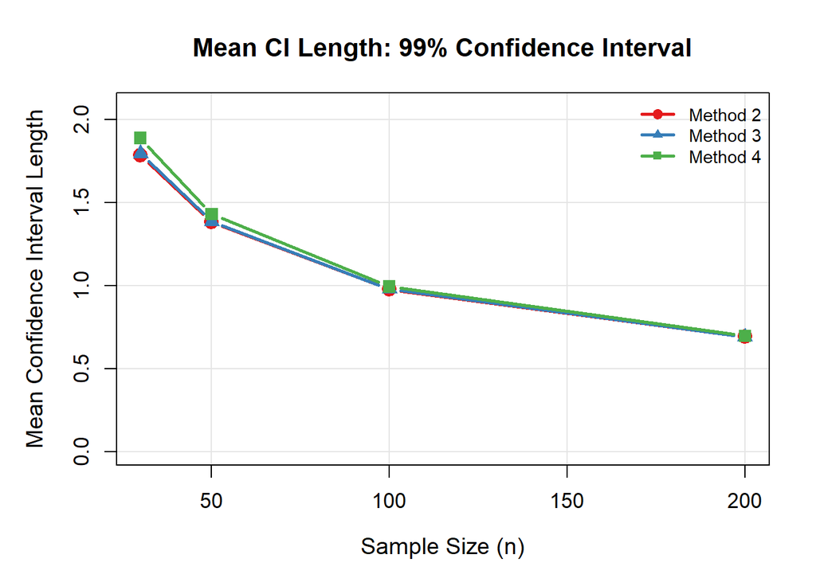

```r
par(mfrow = c(1, 1), mar = c(5, 5, 4, 2))
j <- 3
alpha <- alpha_list[j]
conf_level <- 1 - alpha

all_lengths <- c(avgLength2[, j], avgLength3[, j], avgLength4[, j])
y_max <- max(all_lengths) * 1.1

plot(n, avgLength2[, j], type = "n",
     ylim = c(0, y_max),
     xlab = "Sample Size (n)",
     ylab = "Mean Confidence Interval Length",
     main = sprintf("Mean CI Length: %.0f%% Confidence Interval",
                    conf_level * 100),
     panel.first = grid(col = "gray90", lty = 1),
     cex.lab = 1.2, cex.main = 1.3, cex.axis = 1.1)

lines(n, avgLength2[, j], type = "b", pch = 19, col = colors[1], lwd = 2.5, cex = 1.4)
lines(n, avgLength3[, j], type = "b", pch = 17, col = colors[2], lwd = 2.5, cex = 1.4)
lines(n, avgLength4[, j], type = "b", pch = 15, col = colors[3], lwd = 2.5, cex = 1.4)

legend("topright",
       legend = method_names,
       col = colors,
       pch = c(19, 17, 15),
       lty = 1,
       lwd = 2.5,
       bty = "n",
       cex = 0.9)
```

**The statistics obtained:** 1. Sample mean 2. Standard error 3. Coverage 4. Confidence interval 5. Critical values 6. Sample variance (S^2) **Justification** of your solution (e.g. refer to the corresponding theorems from probability theory); Part / method 2: normal approximation.
for large n by CLT we know that sample mean converges to normal distribution with parameters E(sample mean) = theta and Var(sample mean) = theta /n (we can say that because we say that X1, X2 … Xn are iid rv)
$$\bar{X} -> N(\theta, \theta/n)$$
converges in distribution.

now we need to standardize it:
$$Z =
\frac{\bar{X} - \theta}{\frac{\sqrt{\theta}}{\sqrt{n}}} = \frac{(\bar{X}
- \theta) * {\sqrt{n}}}{\sqrt{\theta}} \approx N(0, 1)$$
Now let’s construct our probability statement (with some confidence level 1 - a so out quantile or critical value will be some z with index a/2 also we can write lower bound with minus because we know that standard normal distribution is symmetrical with mean 0):
$$P(-z_{a/2} <= \frac{(\bar{X} - \theta) *
{\sqrt{n}}}{\sqrt{\theta}} <= z_{a/2}) = 1-a$$
We need to express theta:
$$P(|\bar{X} - \theta| <=
z_{a/2} * \frac{\sqrt{\theta}}{\sqrt{n}}) = 1-a$$
$$P(\bar{X} - z_{a/2} * \frac{\sqrt{\theta}}{\sqrt{n}} <= \theta <=
\bar{X} + z_{a/2} *\frac{\sqrt{\theta}}{\sqrt{n}} ) = 1 - a$$
which would be our critical region. But as we learned we cannot have theta in the intervals because it cannot depend on it when we are estimating.

Part / method 3: Now we fully express theta and for this we use quadratic equation:

$$|\bar{X} - \theta| <= z_{a/2} *
\frac{\sqrt{\theta}}{\sqrt{n}}$$

If I square both parts of the equation everything will be okay because we can do that with absolute value (squared values are always positive so we ensure that)
$$(\bar{X} -
\theta)^2 <= z_{a/2}^2 * \frac{\theta}{n}$$
Now let`s expend our quadratic equation:
$$\bar{X}^2 -
2*\theta*\bar{X} +\theta^2 <= z_{a/2}^2 * \frac{\theta}{n}$$
$$\bar{X}^2 - 2*\theta*\bar{X} +\theta^2 -
z_{a/2}^2 * \frac{\theta}{n} <= 0$$
$$\theta^2 - (2\bar{X} + \frac{z_{a/2}^2}{n})*
\theta + \bar{X}^2 <= 0$$
$$D = b^2 - 4ac = (2\bar{X} + \frac{z_{a/2}^2}{n})^2 - 4 * 1 * \bar{X}^2=
4\bar{X} + \frac{4\bar{X}z_{a/2}^2}{n} + \frac{z_{a/2}^4}{n^2} -
4\bar{X}$$
$$D =
\frac{4\bar{X}z_{a/2}^2}{n} + \frac{z_{a/2}^4}{n^2}$$
$$\theta_1 = \frac{2\bar{X} + \frac{z_{a/2}^2}{n} - \sqrt{
\frac{4\bar{X}z_{a/2}^2}{n} + \frac{z_{a/2}^4}{n^2}}}{2}$$
$$\theta_2 = \frac{2\bar{X} +
\frac{z_{a/2}^2}{n} + \sqrt{ \frac{4\bar{X}z_{a/2}^2}{n} +
\frac{z_{a/2}^4}{n^2}}}{2}$$
$$P(\frac{2\bar{X} + \frac{z_{a/2}^2}{n} - \sqrt{
\frac{4\bar{X}z_{a/2}^2}{n} +
\frac{z_{a/2}^4}{n^2}}}{2}<=\theta<=\frac{2\bar{X} +
\frac{z_{a/2}^2}{n} + \sqrt{ \frac{4\bar{X}z_{a/2}^2}{n} +
\frac{z_{a/2}^4}{n^2}}}{2}) = 1-a$$
This is much better because we don’t use theta in intervals for theta. And this method is much more stable for same reason.

Part / method 4:

We don’t know either variance (out unknown parameter theta) or standard deviation so we must find empirical sd or standard error which is sqrt of:
$$S^2 = \frac{\sum_{i=1}^{n}(X_i
- \bar{X})^2}{n-1}$$
S^2 -> a.e theta by SLLN as n-> inf for Poisson(theta)
$$\frac{\sqrt{n}(\bar{X}-\theta)}{s} \approx t_{n-1}
(studentDistibutionWithN-1 Degrees Of Fredom)$$
Now let’s construct probability statement for some a < 0.5:
$$P(-t_{n-1,a/2} <=
\frac{\sqrt{n}(\bar{X}-\theta)}{s} <= t_{n-1,a/2}) = 1-a$$
$$P(\bar{X}-\frac{s* t_{n-1,a/2}}{\sqrt{n}} <=
\theta <= \bar{X}+ \frac{s* t_{n-1,a/2}}{\sqrt{n}}) = 1-a$$
And this is last but not the least method: it uses in intervals only observed data. **Conclusion** (e.g. how reliable your answer is, if it agrees with common sense expectations):

The simulation results confirm the validity of the Central Limit Theorem (CLT) for the Poisson distribution with parameter theta = 3.6. As the sample size increases n -> 200 the coverage probability for all three methods converges to the nominal confidence levels 1 – alpha. This indicates that for n >= 30, the sampling distribution of the mean is sufficiently Gaussian to justify the use of normal-theory approximations.

**Comparative interval length**

**Method 2:** As expected, the interval constructed using the known variance - theta produced the narrowest average length. However, this estimator is purely theoretical.

**Method 3 vs Method 4:** Method 3 is theoretically stronger because it builds the interval using the true Poisson definition (Variance = Mean). Method 4 ‘decouples’ these two values by calculating the standard deviation independently, which adds unnecessary uncertainty in small samples

**General conclusion:**

For General Application I would use method 4. The loss of precision compared to the exact Quadratic method is negligible for moderate-to-large samples, and the computational simplicity (using standard error) outweighs the algebraic complexity of solving quadratic roots.

For High-Precision/Small Sample Scenarios: I would use method 3. It is the mathematically superior estimator as it relies on the pivotal quantity derived directly from the Poisson variance structure without introducing the additional variability of the sample standard deviation $S$.

I would never / really rarely use method 2 or in something theoretical. **Conclusion** (e.g. how reliable your answer is, if it agrees with common sense expectations).

[figure not shown]

**Task 3**

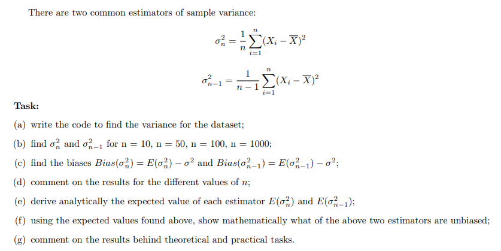

```r
id <- 36
set.seed(id)
N <- 100
mu <- 10
sigma_squared <- 4
sigma <- sqrt(sigma_squared)
dataset <- rnorm(N, mean = mu, sd = sigma)
head(dataset)
```

```
[1] 10.623463 11.699658 11.411066 13.399857  7.308858  8.860373
```

```r
cat("Population Mean (mu):", mu, "\n")
```

```
Population Mean (mu): 10
```

```r
cat("Population Variance (sigma_squared):", sigma_squared, "\n")
```

```
Population Variance (sigma_squared): 4
```

```r
sample_mean <- mean(dataset)
sample_variance <- var(dataset)
biased_variance <- sum((dataset - mean(dataset))^2) / N
cat("Sample Mean:", sample_mean, "\n")
```

```
Sample Mean: 10.11336
```

```r
cat("Sample Variance:", sample_variance, "\n")
```

```
Sample Variance: 3.170323
```

```r
cat("Variance:", biased_variance, "\n")
```

```
Variance: 3.138619
```

```r
n_values <- c(10, 50, 100, 1000)
for (n in n_values){
  sigma_n_squared <- sum((dataset - sample_mean)^2)/n
  cat("for n ", n, "sigma n squared", sigma_n_squared, "\n")
  sigma_n_minus1_squared <- sum((dataset - sample_mean)^2)/(n-1)
  cat("for n ", n, "sigma n-1  squared", sigma_n_minus1_squared, "\n")

  bias_sigma_n_squared <- sigma_n_squared - sigma_squared
  cat("Bias for sigma n squared", bias_sigma_n_squared, "\n")
  bias_sigma_n_minus1_squared <- sigma_n_minus1_squared - sigma_squared
  cat("Bias for sigma n - 1 squared", bias_sigma_n_minus1_squared, "\n")
}
```

```
for n  10 sigma n squared 31.38619
for n  10 sigma n-1  squared 34.87355
Bias for sigma n squared 27.38619
Bias for sigma n - 1 squared 30.87355
for n  50 sigma n squared 6.277239
for n  50 sigma n-1  squared 6.405346
Bias for sigma n squared 2.277239
Bias for sigma n - 1 squared 2.405346
for n  100 sigma n squared 3.138619
for n  100 sigma n-1  squared 3.170323
Bias for sigma n squared -0.8613806
Bias for sigma n - 1 squared -0.8296774
for n  1000 sigma n squared 0.3138619
for n  1000 sigma n-1  squared 0.3141761
Bias for sigma n squared -3.686138
Bias for sigma n - 1 squared -3.685824
```